# Preventable Emergency Service Costs

I. Blakley

11/10/2017

# Intro

Patients who cannot afford to get outpatient care are forced to rely on emergency services. This shifts the cost of care to the state, the hospital, the insurance company, and the total cost is far higher than the outpatient care would have been, but the individual cannot afford that care and must defer the cost in this way. This results in unnecisarily high costs to the state and decreased overall care for the individual.

The goal of this analysis is to identify diagnosis that should be targets for programs that cover the cost of care for individual who cannot afford it, event after insurance covers some or most of it. These programs could be paid for by the same entities that would have had to pay for the ED visit, and while that may sound unfair, it is ultimatley a savings for them.

limitations -I don’t know the time span of the data we have. This may represent 10 years or 6 months, I don’t know. -I don’t know what the cost to the individual is. If patients are not getting care event thought there is no cost to them, then creating a service to pay for the care will not change anything.

```r
# bh for behavioral claims
fname = "/Users/ivory/Google Drive/IvorysPersonalDrive/Queen_City_Hackathon/dataset/Health Claims Data/BH_claims_Hackathon.csv"
bh = read.table(fname, sep=",", header=T, quote='"')
bh$HackID = as.character(bh$HackID)

# ph for physical claims
fname = "/Users/ivory/Google Drive/IvorysPersonalDrive/Queen_City_Hackathon/dataset/Health Claims Data/Hackathon_physical_claims.csv"
ph = read.table(fname, sep=",", header=T, quote='"')
ph$hackID = as.character(ph$hackID)

# hi for Hack ID, the primary key for this table
fname = "/Users/ivory/Google Drive/IvorysPersonalDrive/Queen_City_Hackathon/dataset/Health Claims Data/Consumer_data.csv"
hi = read.table(fname, sep=",", header=T, quote='"')

bOnly = unique(bh$HackID[which(!bh$HackID %in% ph$hackID)])
pOnly = unique(ph$hackID[which(!ph$hackID %in% bh$HackID)])
```

There are 64 individuals that are only in the physical claims dataset, and 0 individuals that are only in the behavioral claims data set.

The hi data matches the number of names in the bh data. Remove those extra names that are only in the ph data.

```r
ph = ph[ph$hackID %in% hi$HackID,]
```

Merge the data sets.

```r
cs = merge(bh, ph, by.x="HackID", by.y="hackID", all=T)

csPonly = cs[cs$HackID %in% pOnly,]
```

There are 70309 unique hack IDs in the merged data.

Classify each individual as crisis or not based on the suggested criteria: Crisis = where ServiceSummary = ED, Inpatient, or Crisis services

```r
#individuals = unique(cs$HackID)
bh$crisis = bh$ServiceSummary %in% c("Emergency Department", "Inpatient", "Crisis Services")
IN = split(bh[,"crisis"], f=bh$HackID)
crisis = sapply(IN, any)
t = table(crisis)
t
```

```
## crisis
## FALSE  TRUE
## 57555 12754
```

Of the 70309 individuals in the data set, 12754 are crisis cases, and 57555 are not.

Take a random 40% of each to make the training set. Let the other 60% be split into 2 test sets.

```r
set.seed(17)
# posCases = names(crisis)[crisis]
# negCases = names(cirsis)[!crisis]
training = sample(crisis, floor(.4*length(crisis)))
testing = crisis[! names(crisis) %in% names(training)]
t.train = table(training)
t.train
```

```
## training
## FALSE  TRUE
## 23041  5082
```

```r
testing1 = sample(testing, floor(.5*length(testing)))
t.test1 = table(testing1)
t.test1
```

```
## testing1
## FALSE  TRUE
## 17208  3885
```

```r
testing2 = testing[! names(testing) %in% names(testing1)]
t.test2 = table(testing2)
t.test2
```

```
## testing2
## FALSE  TRUE
## 17306  3787
```

Save a table of the training outcomes.

```r
df.train = data.frame(HackID = names(training), crisis=training)
write.table(df.train, "outcomes_training.csv",col.names = T, row.names = F, sep=",")
df.test1 = data.frame(HackID = names(testing1), crisis=testing1)
write.table(df.test1, "outcomes_testing1.csv",col.names = T, row.names = F, sep=",")
df.test2 = data.frame(HackID = names(testing2), crisis=testing2)
write.table(df.test2, "outcomes_testing2.csv",col.names = T, row.names = F, sep=",")
```

Reshape the data so we have a table with rows representing HackID and columns corresponding to diagnosis id’s taken from the MAIN column of the physical claims sheet.

```r
library(reshape2)
main = dcast(data=ph[,c("Main","hackID","count_claims")], formula = hackID~Main, fun.aggregate=sum)
row.names(main) = main$hackID
```

Notice that where the Main column had no value (an empty string) that was also made into a column, which it calls “Var.2”. We don’t need to keep that column.

```r
main = main[,names(main)!="Var.2"]
```

Merge the diagnosis data with the other data we have for the individuals.

```r
perHackID = merge(hi, main, by.x="HackID", by.y="hackID", all=T)
row.names(perHackID) = perHackID$HackID
write.table(perHackID, "perHackID.csv",col.names = T, row.names = F, sep=",")
main = main[names(training),]
```

```r
df = perHackID[names(training),2:ncol(perHackID)]
DF = split(df, f=training)
df = sapply(df, as.factor)
```

with just the diagnoses:

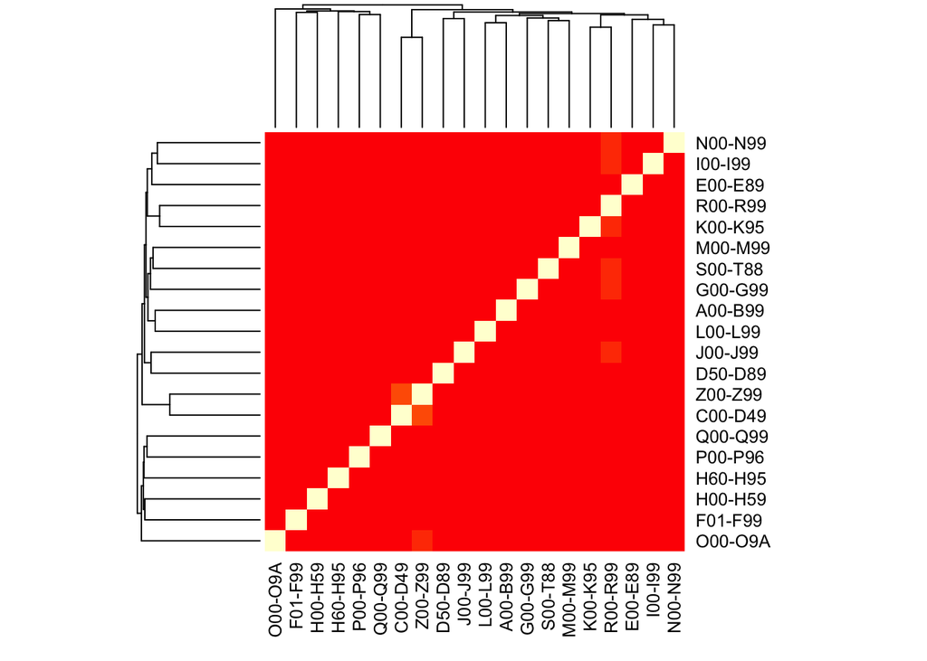

```r
row.names(main) = main$hackID
main = main[,names(main) %in% ph$Main]
# correlation in main
heatmap(cor(main))
```

Set all values to 1 or 0.

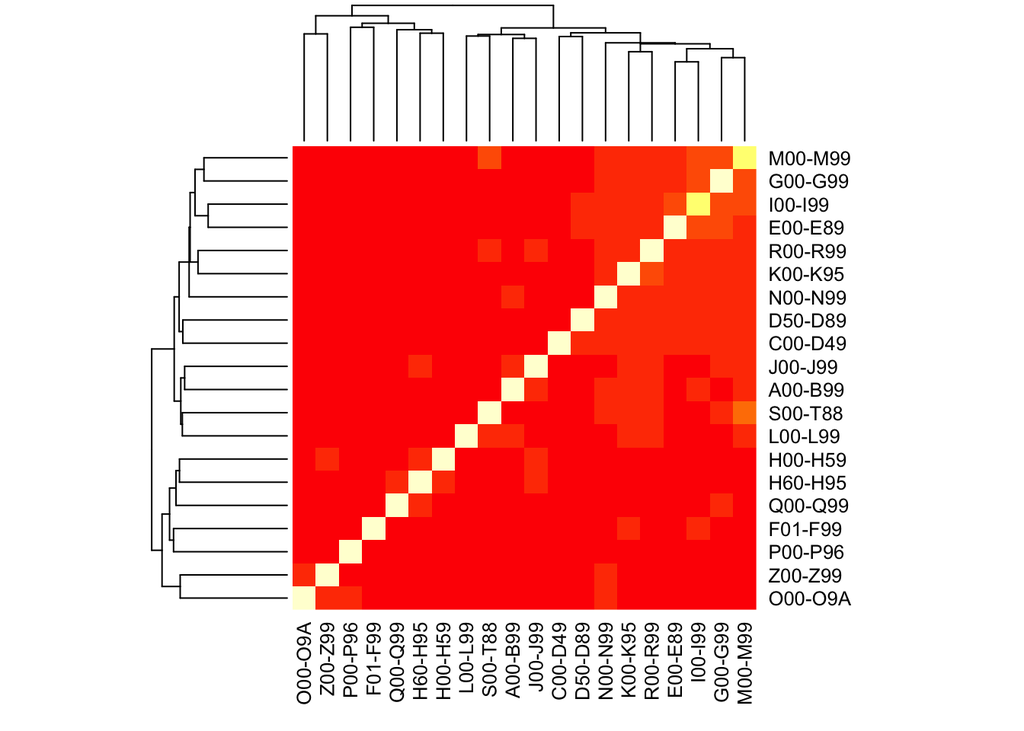

```r
rn = row.names(main)
main01 = sapply(main, FUN=function(x){as.numeric(x>0)})
row.names(main01)=rn
heatmap(cor(main01))
```

Add outcome.

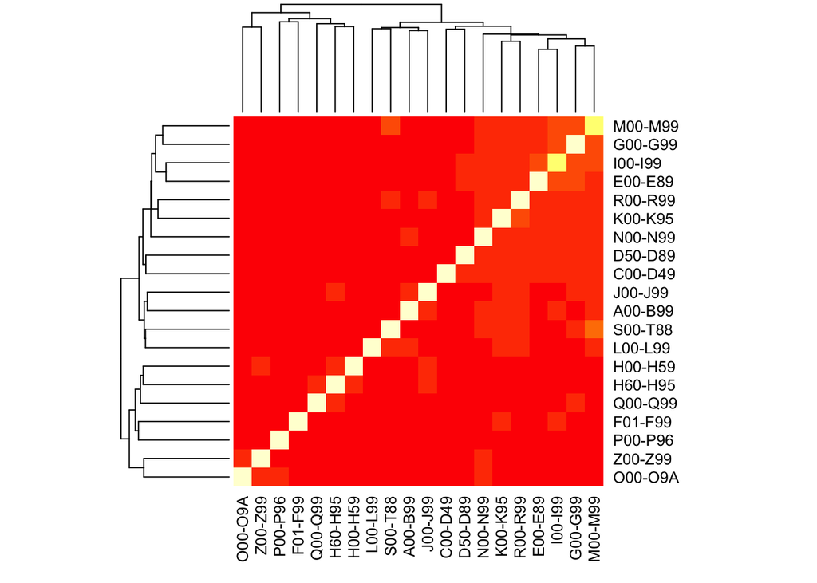

```r
outcome = as.numeric(training[row.names(main01)])
main = cbind(outcome, main01)
heatmap(cor(main01))
```

```r
pred = perHackID[names(training),2:ncol(perHackID)]
# pred[,1] = training
# names(pred)[1] = "outcome"
```

Train model

```r
# library(caret)
# model = train(x=pred, y=training)
```

```r
model = glm(data=data.frame(main01), formula = outcome ~.)
coefs=model$coefficients
coefs = coefs[order(abs(coefs), decreasing = T)]
coefs
```

```
##     R00.R99     P00.P96     S00.T88 (Intercept)     Q00.Q99     F01.F99
##  0.12173820 -0.11744485  0.11470854  0.08427815 -0.07591465  0.07397917
##     H60.H95     O00.O9A     H00.H59     J00.J99     C00.D49     G00.G99
## -0.05505474  0.05231933 -0.04149728 -0.03985671 -0.03088598 -0.02537857
##     N00.N99     L00.L99     I00.I99     Z00.Z99     E00.E89     K00.K95
##  0.02042626 -0.02027321  0.01581970 -0.01374044 -0.01273375  0.01261884
##     D50.D89     M00.M99     A00.B99
##  0.01197531  0.01002385 -0.01002368
```

Of the crisis cases, what are the diagnoses in the claims that are the crisis?

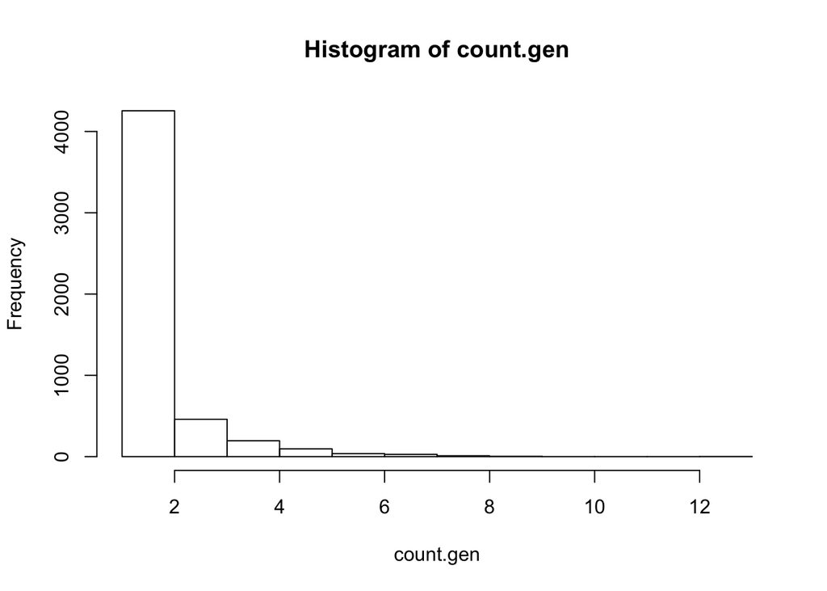

```r
# consider the crisis cases from the training set
bh.cri = bh[bh$crisis & bh$HackID %in% names(training),]
# separate by patient
BHC = split(bh.cri, f=bh.cri$HackID)
# specific = sapply(BHC, function(x){unique(as.character(x$DiagnosisCode))})
# count.spec = sapply(specific, length)
# hist(count.spec)
general = sapply(BHC, function(x){unique(substr(as.character(x$DiagnosisCode),1,3))})
count.gen = sapply(general, length)
hg=hist(count.gen)
```

For 3220 individuals, their crisis claims only include one type of general diagnosis. For 1862 individuals, their crisis claims include 2 or more general diagnosis categores.

What are the common diagnoses among the singe-diagnosis cases?

```r
sDiags = table(unlist(general[names(count.gen)[count.gen==1]]))
sDiags
```

```
##
## F01 F02 F03 F05 F06 F07 F09 F10 F11 F12 F13 F14 F15 F16 F17 F19 F20 F22
##   9   2  52  16   8  43   1 306 194  37  18  76  10   1  16  56 125  11
## F23 F25 F28 F29 F30 F31 F32 F33 F34 F39 F40 F41 F42 F43 F44 F45 F48 F50
##   8 127   4  36   6 203 393 251  32  17   2 457   2 226  36  16   2   2
## F51 F52 F53 F54 F59 F60 F63 F68 F71 F72 F73 F79 F80 F84 F89 F90 F91 F94
##   4   1   3   1   1  17   6   1   4   1   1   3   1  40   1  71 120   1
## F95 F98 F99 G30 G40 G44 G93 J44 O99 R41 R45 R69 T76 Z03 Z55 Z72
##   4   5  20   9   1  61   2   1   4   3  25   1   1   1   1   3
```

```r
mDiags = table(unlist(general[names(count.gen)[count.gen>1]]))
mDiags
```

```
##
## F01 F02 F03 F05 F06 F07 F09 F10 F11 F12 F13 F14 F15 F16 F17 F18 F19 F20
##  12   2  19  14  44  10   1 190 128  70  31 132  23   2   4   2 128 269
## F22 F23 F25 F28 F29 F30 F31 F32 F33 F34 F39 F40 F41 F42 F43 F44 F45 F48
##  29  59 282   5 182  15 449 734 554 189 143   9 249   9 292  15   3  10
## F50 F52 F53 F60 F63 F64 F68 F69 F70 F71 F72 F79 F81 F84 F89 F90 F91 F93
##   2   2   4  79  30   1   3   1  11   8   3  19   1  39   1 128 228   1
## F94 F98 F99 G30 G44 G47 I71 N17 O26 O75 O99 Q87 R41 R44 R45 S06 T39 T40
##   5  11  45   6   5   1   1   1   2   1  11   1   1   4 258   1   1   2
## T43 Z62 Z76 Z86 Z91
##   1   1   2   1   1
```

```r
#m = merge(data.frame(diag=names(sDiags), sDiags=as.numeric(sDiags)),data.frame(diag=names(mDiags), mDiags=as.numeric(mDiags)))
```

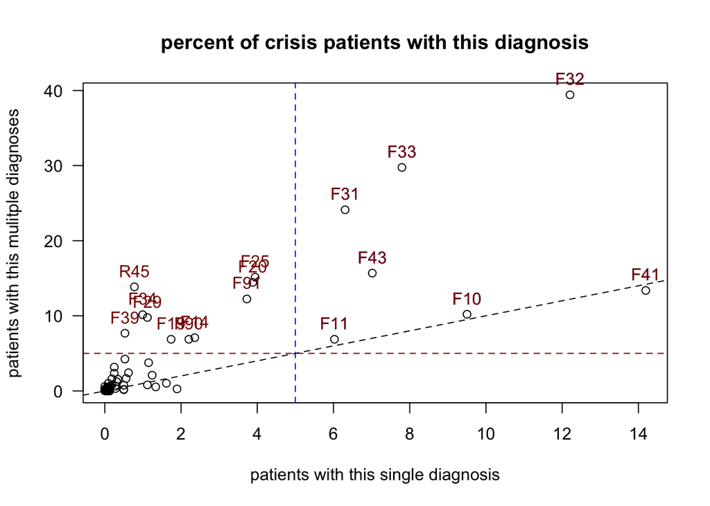

```r
# divide each count (patient with the diagnosis) by the number of patients in each category (single diagnosis or mulit-diagnosis)
sDiagsFrac = sDiags/sum(count.gen == 1) *100
mDiagsFrac = mDiags/sum(count.gen > 1) *100
m = merge(data.frame(diag=names(sDiagsFrac),
                                         sDiags=as.numeric(sDiagsFrac)),
                    data.frame(diag=names(mDiagsFrac),
                                         mDiags=as.numeric(mDiagsFrac)),
                    all=T)
m[is.na(m)] = 0
plot(m$sDiags, m$mDiags, las=1,
         xlab="patients with this single diagnosis",
         ylab="patients with this mulitple diagnoses",
         main="percent of crisis patients with this diagnosis")
abline(a=0, b=1, lty=2)
bigX=5
abline(v=bigX, col="blue", lty=2)

bigXvals=which(m$sDiags>bigX)
text(x=m$sDiags[bigXvals], y=m$mDiags[bigXvals], labels = m$diag[bigXvals], pos=3, xpd=T, col="darkblue")

bigY = 5
#abline(a=bigY, b=1, lty=2, col="red")
abline(h=bigY, col="darkred", lty=2)

bigYvals=which(m$mDiags > bigX)
text(x=m$sDiags[bigYvals], y=m$mDiags[bigYvals], labels = m$diag[bigYvals], pos=3, xpd=T, col="darkred")
```

A few diagnoses are heavy hitters.

```r
hh = m$diag[intersect(bigXvals, bigYvals)]
hh = as.character(hh)
hh
```

```
## [1] "F10" "F11" "F31" "F32" "F33" "F41" "F43"
```

Lets try to focus on the crisis cases that include these heavy-hitter diagnoses.

```r
perHackID_2 = perHackID
perHackID_2$crisis = crisis[perHackID_2$HackID]
# everyone who was previously non-crisis is still non-crisis.
perHackID_2$newCrisis = NA
perHackID_2$newCrisis[perHackID_2$crisis==FALSE] = FALSE
# crisis cases where the patien has one of the heavy hitters, are newCrisis cases
bh$dcGen = substr(bh$DiagnosisCode,1,3)
#hh
bh$dcGenHH = bh$dcGen %in% hh
newCrisisCases = row.names(bh)[bh$dcGenHH & bh$crisis]
#newCrisisCases = sapply(general, function(x){length(intersect(x,hh))>0})
#newCrisis = perHackID_2$HackID %in% names(newCrisisCases)[newCrisisCases]
#perHackID_2$newCrisis = newCrisis & perHackID_2$crisis
perHackID_2[newCrisisCases,"newCrisis"] = TRUE
# old crisis cases that don't meet this criteria will be NA
perHackID_2$newCrisis [perHackID_2$crisis & !perHackID_2$newCrisis] = NA
```

Based on this new criteria for crisis, make a training and testing set.

```r
# throw away the cases that are old crisis cases but not new crisis cases
perHackID_2 = perHackID_2[!is.na(perHackID_2$newCrisis),]
# training
train = sample(x=row.names(perHackID_2), floor(.4*nrow(perHackID_2)) )
df.train = perHackID_2[train,c("HackID","newCrisis")]
table(df.train$newCrisis)
```

```
##
## FALSE  TRUE
##   134  6268
```

```r
names(df.train) = c("HackID","crisis")
write.table(df.train, "outcomes_training_hhCrisis.csv",col.names = T, row.names = F, sep=",")

forTesting = !row.names(perHackID_2) %in% train
testing = perHackID_2[forTesting,c("HackID","newCrisis")]
table(testing$newCrisis)
```

```
##
## FALSE  TRUE
##   183  9421
```

```r
test1 = sample(x=row.names(testing), floor(.5*nrow(testing)) )
test1DF = testing[test1,c("HackID","newCrisis")]
test2DF = testing[!row.names(testing) %in% test1,c("HackID","newCrisis")]

write.table(df.test1, "outcomes_testing1_hhCrisis.csv",col.names = T, row.names = F, sep=",")
write.table(df.test2, "outcomes_testing2_hhCrisis.csv",col.names = T, row.names = F, sep=",")
```

```r
bhOut = bh[bh$ServiceSummary=="Outpatient",]
bhOut = split(bh[,"numberofClaims"], f=bh$HackID)
bhOut = sapply(bhOut, sum)

OutPatientCare = bhOut[row.names(perHackID)]
perHackID.out = cbind(perHackID, OutPatientCare)
write.table(perHackID.out, "perHackID_OutClaims.csv",col.names = T, row.names = F, sep=",")
```

Did recieving Outpatient care make a difference in crisis grouping?

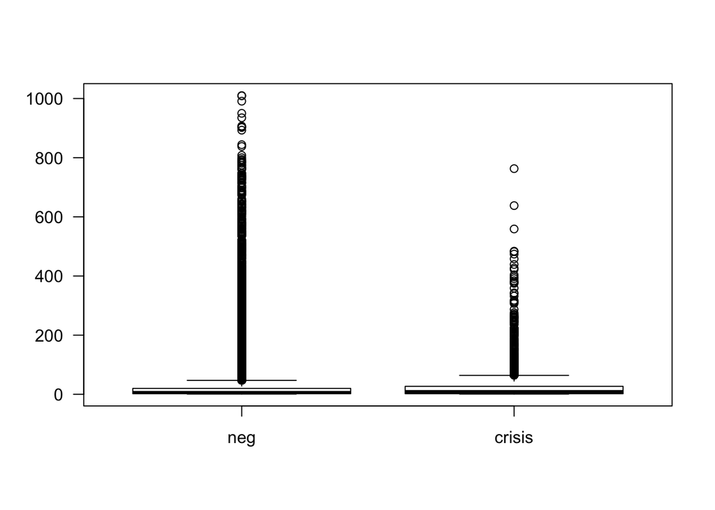

```r
pos = names(training)[training]
neg = names(training)[!training]
boxplot(list(neg=perHackID.out[neg,"OutPatientCare"], crisis=perHackID.out[pos,"OutPatientCare"]),
                las=1)
```

Does the total cost of the outpatient care make a difference?

```r
bhOutCost = bh[bh$ServiceSummary=="Outpatient",]
bhOutCost = split(bh[,"total_amount"], f=bh$HackID)
bhOutCost = sapply(bhOutCost, sum)

OutPatientCareCost = bhOutCost[row.names(perHackID)]
perHackID.out = cbind(perHackID, OutPatientCareCost)
#write.table(perHackID.out, "perHackID_OutClaims.csv",col.names = T, row.names = F, sep=",")

# boxplot(list(neg=perHackID.out[neg,"OutPatientCareCost"], crisis=perHackID.out[pos,"OutPatientCareCost"]),
#               las=1)
# plot(x=jitter(as.numeric(factor(bh$crisis))),
#        y=bh[,"OutPatientCareCost"])
```

```r
# bh$dcGen = substr(bh$DiagnosisCode,1,3)
# hh
# bh$dcGenHH = bh$dcGen %in% hh
```